# Order Statistics

### November 1, 2021

```r
library(dplyr)
library(tidyverse)
```

# Introduction

Order Statistics are when we have a set of random variables, *X<sub>1</sub>*, *X<sub>2</sub>*,…, *X<sub>N</sub>* that are IID (independent and identically distributed). These values are in ascending order and can be used to describe the distribution of the data. In this deliverable I will use order statistics to show how they can be useful in how we perceive any given distribution.

# Background

To use order statistics to describe data and their distributions, you need to know which order represents which descriptive measure. For instance, the first order statistic is represented by *X<sub>1</sub>* and is the minimum, while *X<sub>N</sub>* is the maximum. We can also find the median by finding which value is represented by *X<sub>N/2</sub>*. To prove that these order statistics are true to their nature, showing the density function, probability function, and quantile function are the best way.

# Density Function for Median

When we write the formula as a function *dorder* and plot the probability density function, we see the graph below with a mean and median around 0. We can also see, and tell from the function below that includes *pnorm*, that the distribution is normally distributed.

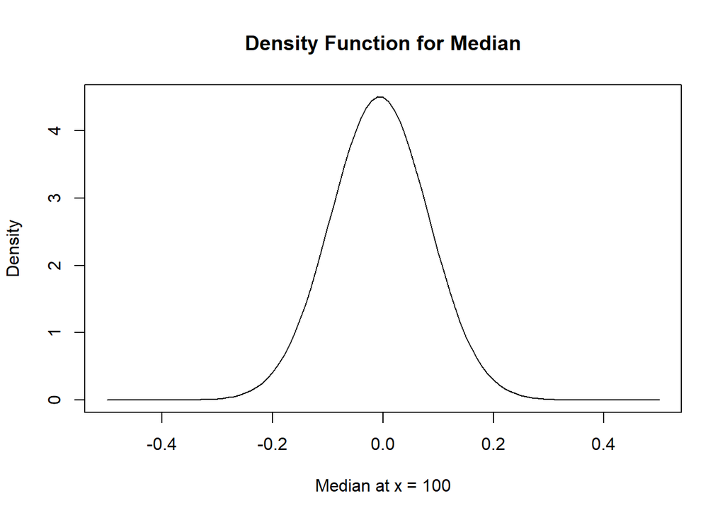

```r
dorder <- function(x){
  100 * choose(200,100) * (pnorm(x))^(100-1) * (1-pnorm(x))^(200-100) * dnorm(x)
}

curve(dorder(x), -0.5, 0.5, main = "Density Function for Median", xlab = "Median at x = 100", ylab = "Density")
```

# Probability Function for Median

The probability function can be written as: $F_{(k)}(x) = \sum_{j=k}^{N}{n \choose j}[F(x)]^{j}[1 - F(x)]^{n-j}$

Very similar to the probability density function above and consistent with a normally distributed dataset (using *pnorm* in the function *porder*) we see once again a mean and median value of around 0. The cumulative density function below shows us that in a dataset of 200, the median is *X<sub>(100)</sub>*.

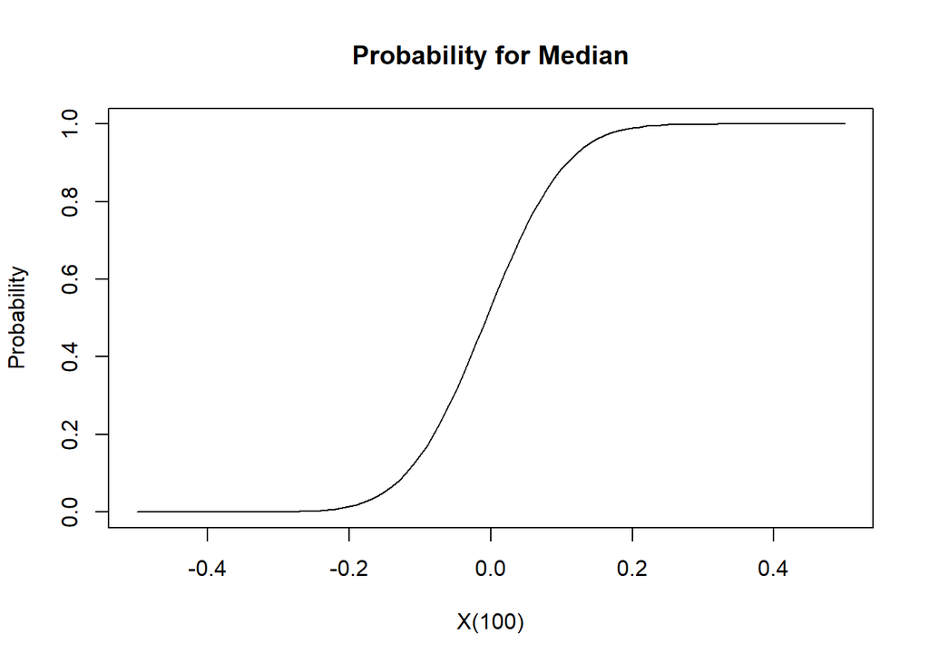

```r
porder <- function(x){
  pbinom(100-1, 200, pnorm(x), lower.tail = FALSE)
}
curve(porder(x), -0.5, 0.5, main = "Probability for Median",
      xlab = "X(100)", ylab = "Probability")
```

# Quantile Function for Median

In the quantile function *qorder* we used the *porder* function from above so we can expect to see results that mimmick those of a normal distribution. When looking at the graph, we can assume that like the two graphs above, our median is either 0 or right around 0. The majority of the probability is between -1 and 1, closer to 0, as we can see from the almost flat black line of the median.

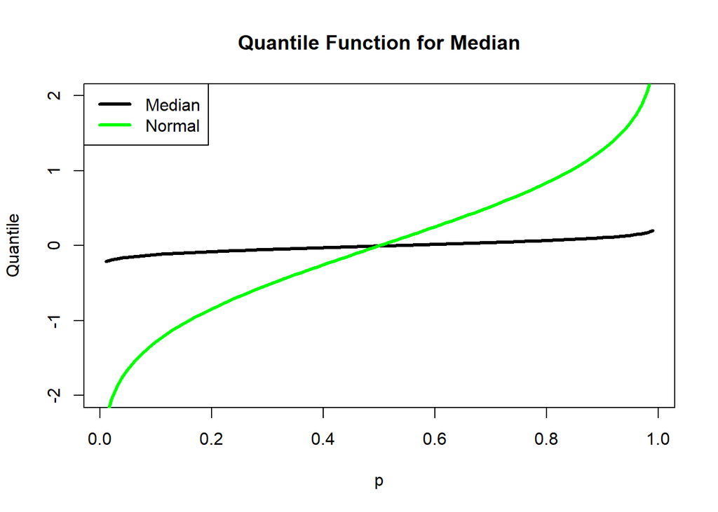

```r
qorder <- function(p){
  out <- p
  for (i in seq_along(p)){
    out[i] <- uniroot(function(x){
      porder(x) - p[i]
      },
      c(-100,100))$root
  }
  out
}

p <- seq(0.01, 0.99, by = 0.01)
plot(p,
     qorder(p),
     type="l",
     ylim=c(-2,2),
     ylab="Quantile",
     lwd=3,
     main = "Quantile Function for Median")
lines(p,
      qnorm(p),
      col="green",
      lwd=3)
legend("topleft",
       c("Median","Normal"),
       col = c("black","green"),
       lwd = 3)
```

# Sampling Distribution for Median Simulation

To create the sampling distribution for the median, we will create a plot of the empirical cumulative distribution function and then overlay this plot ontop of the theoretical CDF to compare. We will run a simulation with 10000 random samples of N = 200. Based on the graph below, we can see some very slight differences between the simulation and theoretical plots, but they are mostly similar. Increasing the simulations will only bring the black and green lines closer together, meaning the simulation will began to closer mimic the theoretical CDF.

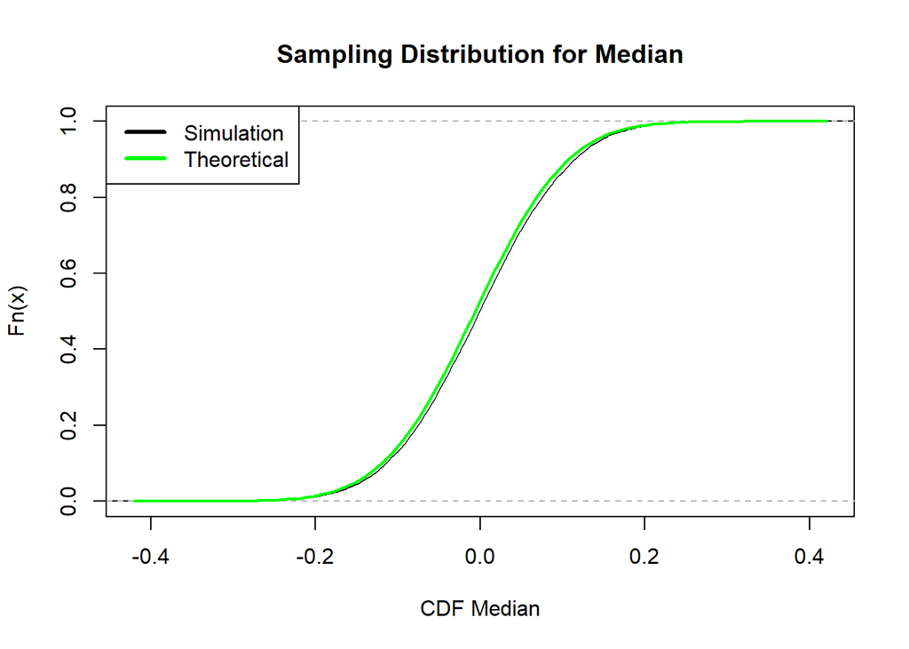

```r
samp <- array(rnorm(200 * 10000, 0, 1), c(10000, 200))
meds <- samp %>%
  apply(1, median)
plot(ecdf(meds),
     xlab = "CDF Median",
     main = "Sampling Distribution for Median")
curve(porder(x), lwd = 2, add = TRUE, col = "green")
legend("topleft",
       c("Simulation","Theoretical"),
       col = c("black", "green"),
       lwd = 3)
```

# Histogram & Density Function

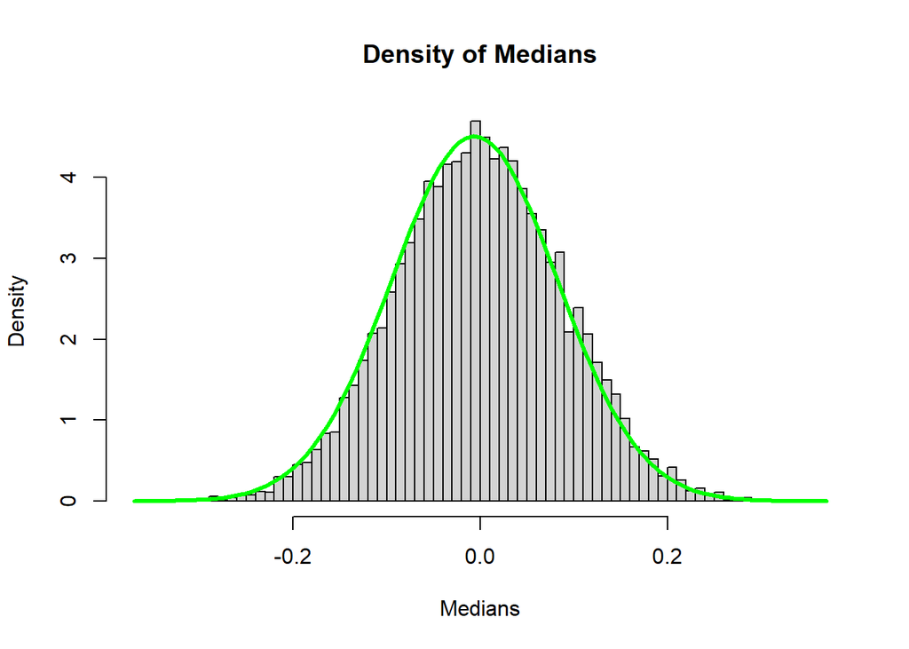

```r
hist(meds, breaks = 100, freq = FALSE,
     main = "Density of Medians",
     xlab = "Medians")
curve(dorder(x), col = "green", add = TRUE, lw = 3)
```

# Q-Q Plot for Sample Median

Q-Q plots are used to compare two probability distributions by plotting their quantiles against each other. We will use a Q-Q plot to compare our theoretical distribution and simulated distribution, with theoretical quantiles on the X-axis and the simulated quantiles on the Y-axis. We will be using the quantile function, *qorder*, to represent the theoretical data and our *meds* value from above to represent the simulated data. The plot below, a straight line with very little variation between -0.2 and 0.2 for both axes, tells us that our simulation is a good match for the theoretical data and follows the same distribution.

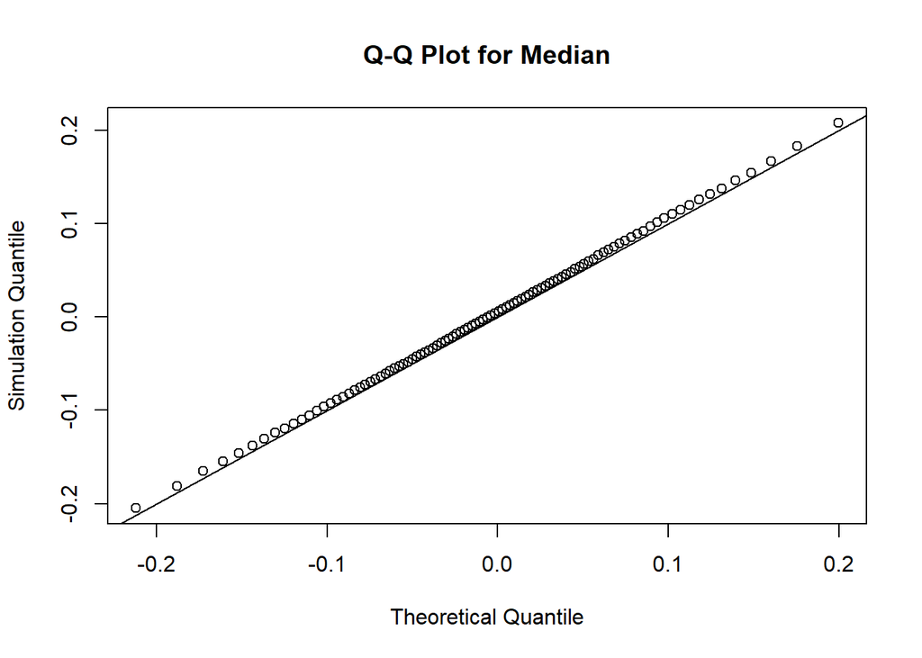

```r
p <- seq(0.01, 0.99, by = 0.01)

x_meds <- qorder(p)
y_meds <- quantile(meds, seq(0.01, 0.99, by = 0.01))
qqplot(x_meds, y_meds,
       main = "Q-Q Plot for Median",
       xlab = "Theoretical Quantile",
       ylab = "Simulation Quantile")
abline(0,1)
```

# K^th Order Statistic

```r
dorderk <- function(x, k){
  k * choose(200, k) * (pnorm(x))^(k - 1) * (1-pnorm(x))^(200 - k) * dnorm(x)
}

porderk <- function(x, k){
  pbinom(k - 1, 200, pnorm(x), lower.tail = FALSE)
}

qorderk <- function(p, k){
  out <- p
  for (i in seq_along(p)){
    out[i] <- uniroot(function(x){
      porderk(x, k) - p[i]
      },
      c(-100, 100))$root
  }
  out
}
```

# Q-Q Plot for Sample Max

After adjusting our *qorder* function to be able to be used for more than just the median, we now have our *qorderk* function to be used for other measures. To create a Q-Q plot, we will compare our theoretical distribution and simulated distribution, with theoretical quantiles on the X-axis and the simulated quantiles on the Y-axis. Using the *qorderk* function, k will equal 200 to represent the maximum value in a dataset where N = 200 to represent the theoretical quantiles and the simulation quantiles will be represented by our *maxs* value. We can see from the Q-Q plot below that the quantiles are a good match and that leads us to believe that the simulated data is a good match for the theoretical data.

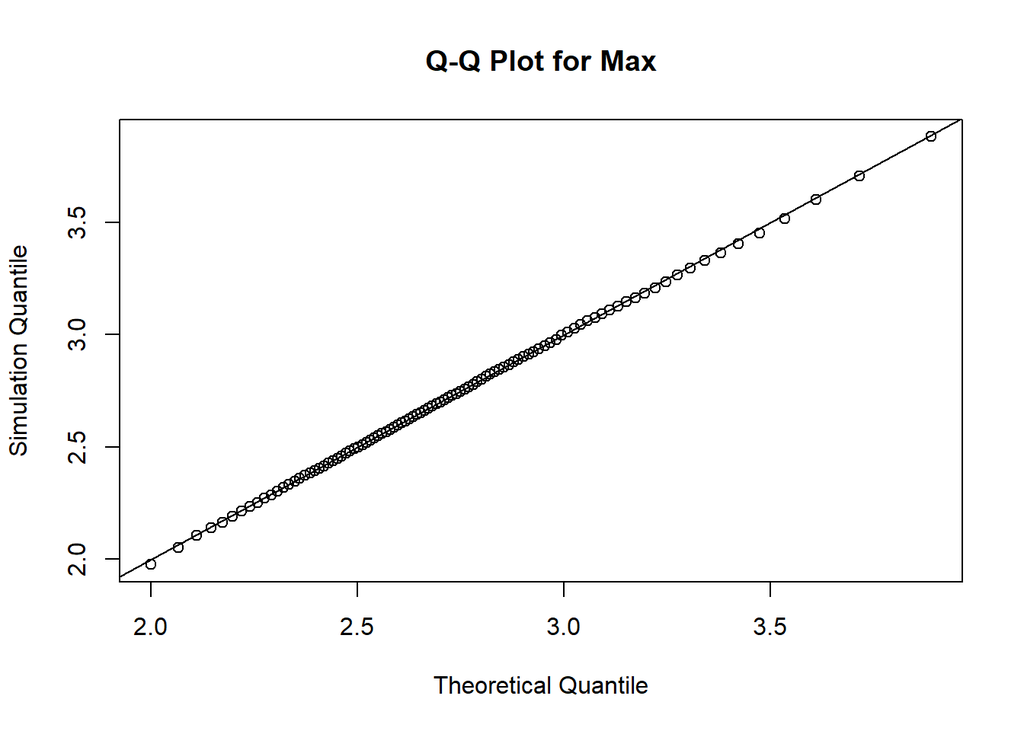

```r
p <- seq(0.01, 0.99, by = 0.01)
samp <- array(rnorm(200 * 10000, 0, 1), c(10000, 200))
maxs <- samp %>%
  apply(1, max)
x <- qorderk(p, 200)
y <- quantile(maxs, seq(0.01, 0.99, by = 0.01))
qqplot(x, y,
       main = "Q-Q Plot for Max",
       xlab = "Theoretical Quantile",
       ylab = "Simulation Quantile")
abline(0,1)
```

# Distribution Modifications

To modify the functions *dorderk*, *porderk*, and *qorderk* from above so that the functions take new parameters `dist` and `...` and work for any continuous distribution, we need to add a few parameters. Since we already modified the functions to find the *K^th* order statistics, we need to add **n** to represent the sample size and **dist** to depict the distribution. To make this work, we need to use the *paste0* function to combine the ‘p’ or ‘d’ to our distributions.

```r
dorderk2 <- function(x, k, n, dist = "norm", ...){
  pf <- get(paste0("p", dist))
  df <- get(paste0("d", dist))
  k *
    choose(n, k) *
    (pf(x, ...))^(k - 1) *
    (1-pf(x, ...))^(n - k) *
    df(x, ...)
}

porderk2 <- function(x, k, n, dist = "norm", ...){
  pf <- get(paste0("p", dist))
  pbinom(k - 1, n, pf(x, ...), lower.tail = FALSE)
}

qorderk2 <- function(x, k, n, dist = "norm", ...){
  out <- p
  for (i in seq_along(p)){
    out[i] <- uniroot(function(x){
      porderk2(x, k, n, dist, ...) - p[i]
      },
      c(-100, 100))$root
  }
  out
}
```

# Probability and Density Functions for Sample Min

### Density For Sample Minimum

Using the modified function above, *dorderk2* and plot the probability density function, we see the graph below. We can also see, and tell from the function below that includes *pnorm*, that the distribution is normally distributed with a minimum value (*1^st* order statistic) between -3 and -2.

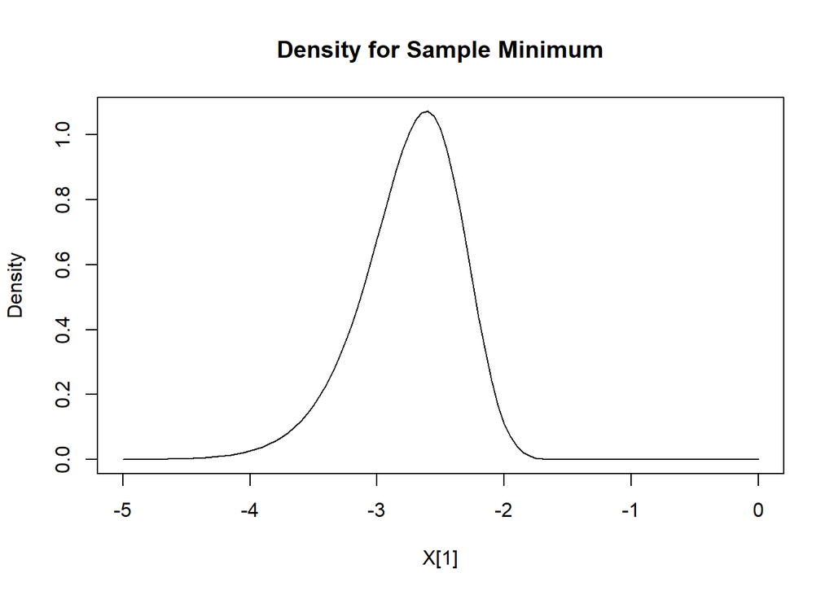

```r
curve(
  dorderk2(x, k = 1, n = 200, dist = "norm"),
  xlim = c(-5,0),
  main = "Density for Sample Minimum",
  xlab = "X[1]",
  ylab = "Density"
)
```

### Probability For Sample Minimum

Very similar to the probability density function above and consistent with a normally distributed dataset (using *pnorm* in the function *porderk2*) we see once again a mean and median value between -2 and -3. The cumulative density function below shows us that in a dataset of 200, the minimum is *X<sub>(1)</sub>*.

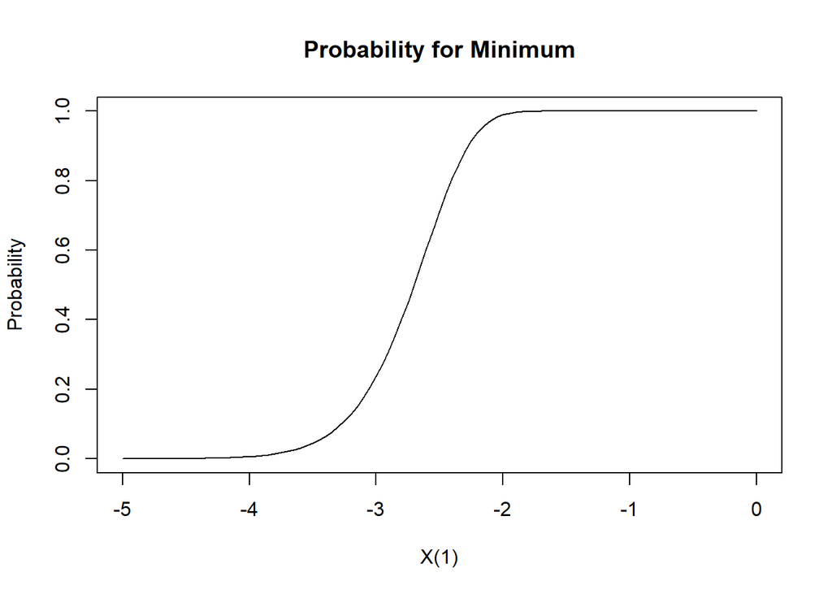

```r
curve(porderk2(x, 1, 200, "norm"),
      xlim = c(-5, 0),
      main = "Probability for Minimum",
      xlab = "X(1)", ylab = "Probability")
```